# DRIP Water Resource Allocation Tool

##### Lisa Rennels and Nick Depsky

##### 11th May 2018

# I. Intro

DRIP is a water resource allocation tool, modeled after [WEAP](http://weap21.org) from the [Stockholm Environment Institute's U.S. Center](https://www.sei.org/centres/us/). WEAP can be summarized as follows:

*WEAP ("Water Evaluation And Planning" system) is a user-friendly software tool that takes an integrated approach to water resources planning.

Freshwater management challenges are increasingly common. Allocation of limited water resources between agricultural, municipal and environmental uses now requires the full integration of supply, demand, water quality and ecological considerations. The Water Evaluation and Planning system, or WEAP, aims to incorporate these issues into a practical yet robust tool for integrated water resources planning. WEAP is developed by the Stockholm Environment Institute's U.S. Center.*

The source code for DRIP is available on [GitHub](https://github.com/lrennels/ER290A-finalproject) and includes several script files as well as input data files to run a small example. In addition to the modeling in Julia, we created a small model in `WEAP` for testing purposes. The required software is proprietary, so it is not included in Github.

# II. User Guide and Example

#### 1. Setup

In order to use DRIP, you will first want to include the helper functions as follows:

```julia
using Weave
include("helper_functions.jl")
```

```julia
(::#8) (generic function with 1 method)
```

Next, set up some basic date information:

```julia
const start_year = 1990
const stop_year = 2017
const tstep = 12
const modays = [31, 28, 31, 30 ,31, 30, 31, 31, 30 ,31, 30 , 31];
```

#### 2. Define Demand

The `DefineDemand.jl` script allows a user to define specific **demand** nodes of which can be of several categories including agricultural, municipal, industrial, and instream flow requirements (IFRs). Each demand nodes has several metadata requirements including

- months - a list of months (*12 by 1 array of Strings*)
- node_type - type of node (*String*)
- name - name of the node (*String*)
- size - size of the node (*Float64*)
- rate - monthly rate of flow through node (*12 by 1 array of Float64*)
- size_units - units of size variable (*String*)
- demand_units = units of rate variable (*String*)
- priority - demand priority (*Int64*)
- Loc- location (or position) in list of all nodes (*Int64*)

```julia
include("DefineDemand.jl")
demand = ddf(demand_nodes, start_year, stop_year)
head(demand)
```

|  | Date | Name | Quantity | Units | Loc |
| --- | --- | --- | --- | --- | --- |
| 1 | 1990-01-01 | City: Berkeley | 1.2e9 | MM3 | 1 |
| 2 | 1990-02-01 | City: Berkeley | 1.2e9 | MM3 | 1 |
| 3 | 1990-03-01 | City: Berkeley | 1.2e9 | MM3 | 1 |
| 4 | 1990-04-01 | City: Berkeley | 1.2e9 | MM3 | 1 |
| 5 | 1990-05-01 | City: Berkeley | 1.2e9 | MM3 | 1 |
| 6 | 1990-06-01 | City: Berkeley | 1.2e9 | MM3 | 1 |

You can also graphically view the demand time series using `dplot`

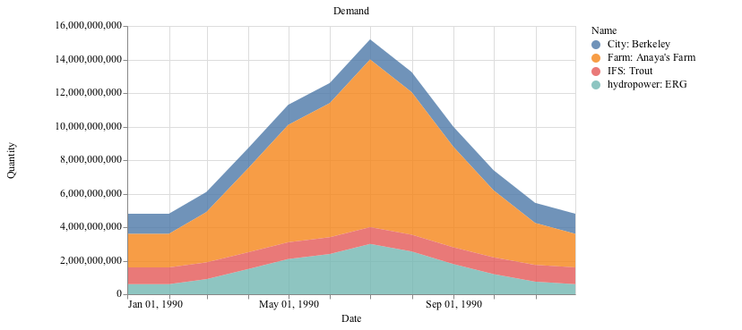

```julia
dplot(demand,1990,1990)
```

#### 3. Define Supply

The `DefineSupply.jl` script allows a user to define specific **supply** nodes of which can be of several categories including tributary inflow, catchment inflows, return flows, and groundwater. Each supply nodes has several metadata requirements including

- filepath - the file path of th e.csv file containing flow information (*String*)
- name - name of supply node (*String*)
- supply_units - units of rate variable (*String*)
- Loc- location (or position) in list of all nodes (*Int64*)

Note that supply information is assumed to be stored in a .csv file in the format of month (Date format) in the first column and Supply (number format) in the second column. Example files can be found in this folder eg. *NYuba_Inflow_Month*.

```julia
include("DefineSupply.jl")
supply = sdf(supply_nodes, start_year, stop_year)
head(supply)
```

|  | Date | Name | Quantity | Units | Loc |
| --- | --- | --- | --- | --- | --- |
| 1 | 1990-01-01 | Headflow | 11.603494113119 | CMS | 1 |
| 2 | 1990-02-01 | Headflow | 9.22421291025 | CMS | 1 |
| 3 | 1990-03-01 | Headflow | 22.4477366842534 | CMS | 1 |
| 4 | 1990-04-01 | Headflow | 30.919810751272 | CMS | 1 |
| 5 | 1990-05-01 | Headflow | 22.4766483000266 | CMS | 1 |
| 6 | 1990-06-01 | Headflow | 17.521922805016 | CMS | 1 |

*The `include` call will return a list of dictionaries, one for each node, and the `sdf` call will convert this data structure into a `DataFrame` for use by the main DRIP script.*

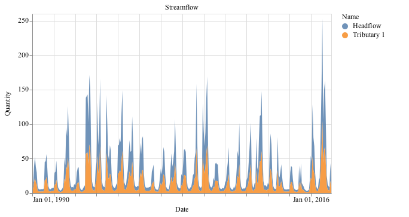

```julia
splot(supply,1990,2017)
```

#### 4. Define Infrastructure

The `DefineInfrastructure.jl` script allows a user to define specific **infrastructure** nodes, which as of now are simply reservoirs. Each infrastructure node has several metadata requirements including

- name - name of reservoir node (*String*)
- storage_capacity - capacity of reservoir (*Float64*)
- init_storage - initial storage of reservoir (*Float64*)
- top_of_conservation - (*12 by 1 array of Float64*)
- storage_units - units of storage (*String*)
- Loc - location (or position) in list of all nodes (*Int64*)

Note that supply information is assumed to be stored in a .csv file in the format of month (Date format) in the first column and Supply (number format) in the second column. Example files can be found in this folder eg. *NYuba_Inflow_Month*.

Once all supply nodes are defined, you can create the structures with an `include` statement and convert them to a DataFrame structure using the `rdf` function as follows:

```julia
include("DefineInfrastructure.jl")
reservoirs = rdf(reservoir_nodes, start_year, stop_year)
```

*The `include` call will return a list of dictionaries, one for each node, and the `rdf` call will convert this data structure into a `DataFrame` for use by the main DRIP script.*

#### 5. Run DRIP

Once you have set up the demand, supply, and reservoir nodes, you can run the main DRIP allocation routine! This allocation script will run the allocation algorithm and return `results`, which is a vector of values between 0 and 1 indicating the fraction of demand fulfilled for that specific demand node.

```julia
include("DRIP_allocation_routine.jl")
results = DRIP_allocation_routine(demand_nodes, supply_nodes, reservoir_nodes,
    (stop_year - start_year + 1))
    results
```

```julia
4-element Array{Float64,1}:
 0.0129429
 0.0129429
 0.0
 0.0129429
```

# III. WEAP Model

In order to benchmark our model against the original WEAP software, we built a small dummy WEAP model of the system constructed in our model. It consists of a single river with headflow represented as a monthly average streamflow time series taken from the USGS hydrologic gauge data repository for the North Yuba River in the California Sierra Nevada. There is a single reservoir with a pre-defined storage capacity and initial storage. Currently there is also a single hydropower plant, a city (Berkeley) demand, a farm demand (Anaya's Farm), and a minimum instream flow requirement (IFR). A schema of the model in WEAP is shown below.

[figure not shown]

This model was run from 1990 to 2017 at a monthly timestep in order to produce result upon which we want to compare out model outputs. However, given the nascent stage of our model, we were yet unable to totally replicate the WEAP outputs, and are currently thinking through the ways in which WEAP likely obtains its optimzation outputs.

Some data inputs:

[figure not shown]

Here are some results of the reservoir storage and demand shortage: Reservoir Shortage

[figure not shown]

Demand Shortage

[figure not shown]

# IV. Future Work

Nick and I are interested in expanding upon this work, and have begun to do so in the `DRIP_allocation_routine_WIP.jl` file. The most significant changes will be to the the allocation algorithms, and include an optimisation component that mirrors the one used in WEAP. A small model of the inner portion of this optimisation can be found in `Excel_Optim_Model.xlsx`.

Published from WeaveDoc.jmd using Weave.jl 0.5.2 on 2018-05-11.